# Download and process MODIS LAI images

Aubrey Dugger

2015-07-21

# Background

We are using WRF-Hydro to predict streamflow for Fourmile Creek at the Orodell USGS gage for the 2013 snowmelt period. We want to obtain MODIS LAI images for our region of interest and insert the processed images into our forcing time series so we can use dynamic LAI in future WRF-Hydro model runs.

Load the rwrfhydro package.

```r
library("rwrfhydro")
```

Set a data path to the Fourmile Creek test case.

```r
dataPath <- '~/wrfHydroTestCases/Fourmile_Creek'
```

# Setup the MODIS-R tool.

NOTE: These tools rely heavily on the [MODIS-R](https://r-forge.r-project.org/projects/modis/) package, so please see their development page and R help pages for more on the package tools and options. A local system [GDAL](http://www.gdal.org/) install is also required.

To start, we need to load a few libraries and then tell MODIS-R where our working directories are. If this is the first time using MODIS-R, we will also need to tell it where the local GDAL libraries live. Your GDAL pathname may vary; type “which gdalinfo” in a terminal window to find the appropriate path for your system. If gdalinfo is not found, make sure you have GDAL installed on your local system.

```r
library(rgeos)
library(rgdal)
library(raster)
library(MODIS)
library(ncdf4)

gdalPath <- sub("gdalinfo", replacement="", system("which gdalinfo", intern=TRUE))
MODISoptions(localArcPath="~/wrfHydroTestCases/MODIS_ARC", outDirPath="~/wrfHydroTestCases/MODIS_ARC/PROCESSED", gdalPath=gdalPath)
```

```
## To install all required and suggested packages run:
##  setRepositories() # activate CRAN, R-forge, and Omegahat and then:
##  install.packages(c(' mapdata '),dependencies=TRUE)
```

```
## Setting 'localArcPath' to '/Volumes/d1/adugger/WRF_Hydro/test_cases/MODIS_ARC'
## If you already have downloaded some HDF-files to '/Volumes/d1/adugger/WRF_Hydro/test_cases/MODIS_ARC' you can use '?orgStruc()' to re-arrange your HDF-data!
## 'outDirPath' has been changed from '/Volumes/d1/adugger/WRF_Hydro/test_cases/MODIS_ARC/PROCESSED' to '/Volumes/d1/adugger/WRF_Hydro/test_cases/MODIS_ARC/PROCESSED'
```

[output not shown]

# Download and process MODIS tiles

Here we download the relevant MODIS tiles and resample to the Fourmile Creek geogrid. The GetMODIS tool calls the MODIS-R runGdal tool to identify the required MODIS tiles to cover the domain, download the appropriate product tiles, mosaic them, and clip/resample (nearest neighbor) to the geogrid extent and resolution. The result will be a directory of processed TIF images in the outDirPath specified in MODISoptions. We specify the geogrid, a start and end date, and the MOD15A2 (FPAR/LAI) MODIS product name.

```r
GetMODIS(geogrdPath=paste0(dataPath, '/DOMAIN/geo_em.d01_1km_nlcd11.nc'), prodName="MOD15A2",
         outDir="FOURMILE_LAI", begin="2013.03.01", end="2013.07.31",
         exclList=list("Fpar_1km"="gt 100",
                       "Lai_1km"="gt 100",
                       "FparLai_QC"="255",
                       "FparExtra_QC"="255",
                       "FparStdDev_1km"="gt 100",
                       "LaiStdDev_1km"="gt 100"),
         resampList=list("Fpar_1km"="bilinear",
                       "Lai_1km"="bilinear",
                       "FparLai_QC"="mode",
                       "FparExtra_QC"="mode",
                       "FparStdDev_1km"="bilinear",
                       "LaiStdDev_1km"="bilinear"),
         quiet=TRUE)
```

```
## ########################
## outProj          =  +proj=lcc +lat_1=30 +lat_2=50 +lat_0=39.940013885498 +lon_0=-105 +x_0=0 +y_0=0 +a=6370000 +b=6370000 +units=m +no_defs  (Specified by raster*/spatial* object)
## pixelSize        =  1000 1000  (Specified by raster* object)
## resamplingType   =  near
## Output Directory =  /Volumes/d1/adugger/WRF_Hydro/test_cases/MODIS_ARC/PROCESSED/FOURMILE_LAI
## ########################
```

Create a raster stack of the downloaded and processed MODIS LAI images. This tool does some additional processing of the images to get them into a more usable format. Specifically, it can remove “no data” values (in this case, we already excluded those before reasmpling in the step above) and can apply product-specific scale factors (in this case, 0.1). See the [MODIS data page](https://lpdaac.usgs.gov/products/modis_products_table) for specifics on valid value ranges and scale factors.

```r
lai.b <- ConvertRS2Stack(paste0(options("MODIS_outDirPath"), '/FOURMILE_LAI'), "*Lai_1km.tif$",
                         begin="2013.03.01", end="2013.07.31",
                         valScale=0.1, valAdd=0)
```

```
## Found 19 files!
## Found 19 files!
```

See the help on ConvertRS2Stack for more details on the processing options.

```r
?ConvertRS2Stack
```

| ConvertRS2Stack | R Documentation |
| --- | --- |

## Convert a set of MODIS images to a raster stack and, optionally, a NetCDF file.

### Description

`ConvertRS2Stack` takes a set of pre-processed MODIS TIF files and creates a raster stack and, optionally, a NetCDF file.

### Usage

```r
ConvertRS2Stack(inPath, matchStr, begin = NULL, end = NULL, noData = NULL,
  noDataQual = "exact", valScale = 1, valAdd = 0, outFile = NULL,
  varName = NULL, varUnit = NULL, varLong = NULL, varNA = -1e+36)
```

### Arguments

[output not shown]

### Details

`ConvertRS2Stack` scans the specified directory and imports pre-processed MODIS TIF files matching the specified expression and combines them into an R raster stack object and, optionally, an output NetCDF file. Files in the input directory should be already processed through the `GetMODIS` tool or follow the same file naming convention used by the MODIS `runGdal` tool. See the R [MODIS](http://r-forge.r-project.org/projects/modis/) package for more on those specifications.

### Value

A raster stack.

### Examples

```r
## Import the already processed LAI TIF images into a raster stack. Use the full time series of images.

lai.b <- ConvertRS2Stack("/d6/adugger/WRF_Hydro/RS/MODIS_ARC/PROCESSED/BCNED_LAI", "*Lai_1km.tif", noData=100, noDataQual="max", valScale=0.1, valAdd=0)

## Export a subset of the already processed LAI TIF images into an output netcdf file

lai.b <- ConvertRS2Stack("/d6/adugger/WRF_Hydro/RS/MODIS_ARC/PROCESSED/BCNED_LAI", "*Lai_1km.tif", begin=c("2011.06.01", end="2011.06.30", noData=100, noDataQual="max", valScale=0.1, valAdd=0, outFile="BCNED_LAI.nc", varName="LAI", varUnit="(m^2)/(m^2)", varLong="Leaf area index")
```

We can export the processed raster stack to a NetCDF file for use outside of R.

```r
ConvertStack2NC(lai.b, outFile=paste0(dataPath, '/ANALYSIS/FOURMILE_LAI_SUM13.nc'), varName="LAI", varUnit="(m^2)/(m^2)", varLong="Leaf area index", varNA=-1.e+36)
```

Let’s take a look at the raster stack we created. List the available layers (labelled by date).

```r
names(lai.b)
```

```
##  [1] "DT2013.03.06" "DT2013.03.14" "DT2013.03.22" "DT2013.03.30"
##  [5] "DT2013.04.07" "DT2013.04.15" "DT2013.04.23" "DT2013.05.01"
##  [9] "DT2013.05.09" "DT2013.05.17" "DT2013.05.25" "DT2013.06.02"
## [13] "DT2013.06.10" "DT2013.06.18" "DT2013.06.26" "DT2013.07.04"
## [17] "DT2013.07.12" "DT2013.07.20" "DT2013.07.28"
```

Plot a few of the images in the LAI raster stack. We can choose which layer to plot by index or name.

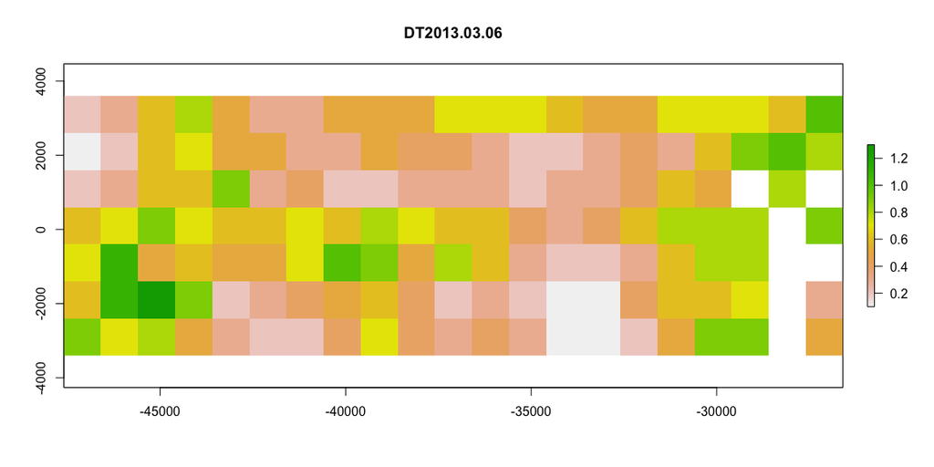

```r
plot(lai.b, 1)
```

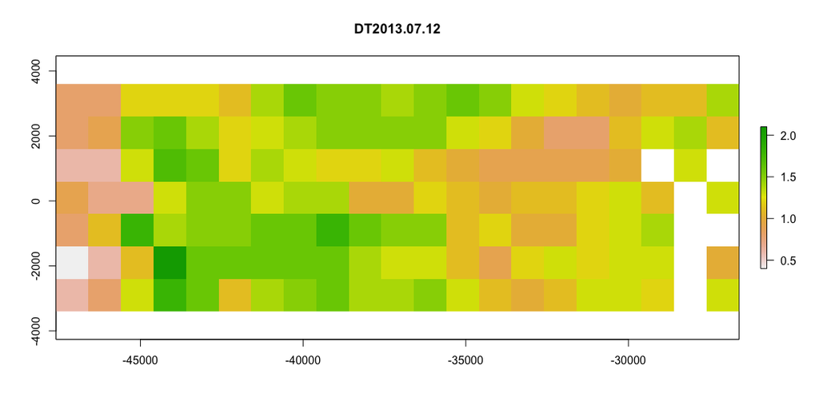

```r
plot(lai.b, "DT2013.07.12")
```

# Apply smoothing filters

Apply a whittaker filter to smooth the LAI time series. This is generally not necessary for a derived product like LAI, but may be useful for products like NDVI, snow cover fraction, vegetated fraction, etc.

Try a highly smoothed filter.

```r
lai.b.sm1 <- SmoothStack(lai.b,
                         outDirPath=paste0(options("MODIS_outDirPath"), '/FOURMILE_LAI_SMOOTH1'),
                         outputAs="one", removeOutlier=TRUE, outlierThreshold=0.5,
                         lambda=2000, overwrite=TRUE)
```

```
## Yearly 'lambda' is: 2000
## Now changed with lambda*('length of input data period in days'/365) to: 783.5616
## Data is in, start processing!
```

Try a less aggressive filter.

```r
lai.b.sm2 <- SmoothStack(lai.b,
                         outDirPath=paste0(options("MODIS_outDirPath"), '/FOURMILE_LAI_SMOOTH2'),
                         outputAs="one", lambda=100, overwrite=TRUE)
```

```
## Yearly 'lambda' is: 100
## Now changed with lambda*('length of input data period in days'/365) to: 39.17808
## Data is in, start processing!
```

Calculate statistics and plot the domain means over time.

```r
stats.lai.b <- CalcStatsRS(lai.b)
stats.lai.b.sm1 <- CalcStatsRS(lai.b.sm1)
stats.lai.b.sm2 <- CalcStatsRS(lai.b.sm2)
```

```r
head(stats.lai.b)
```

| mean | min | max | sd | POSIXct |
| --- | --- | --- | --- | --- |
| 0.5407 | 0.1 | 1.3 | 0.3119 | 2013-03-06 |
| 0.5386 | 0.1 | 1.2 | 0.2389 | 2013-03-14 |
| 0.465 | 0.1 | 0.9 | 0.2081 | 2013-03-22 |
| 0.6664 | 0 | 1.7 | 0.2591 | 2013-03-30 |
| 0.6886 | 0 | 1.3 | 0.2916 | 2013-04-07 |
| 0.2236 | 0 | 0.6 | 0.1084 | 2013-04-15 |

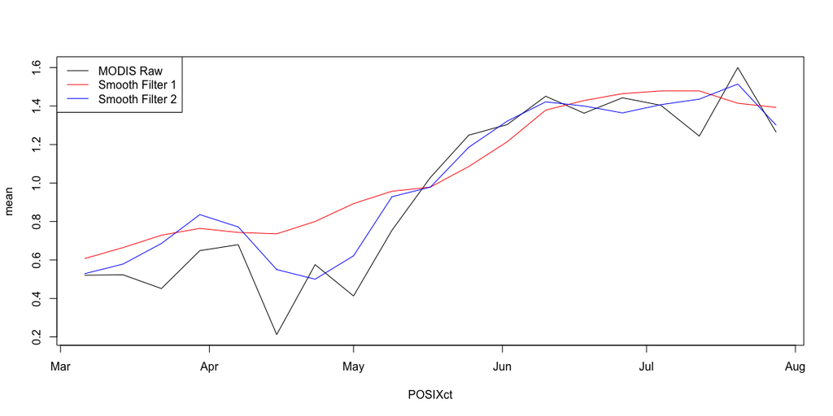

```r
with(stats.lai.b, plot(POSIXct, mean, typ='l'))
with(stats.lai.b.sm1, lines(POSIXct, mean, col='red'))
with(stats.lai.b.sm2, lines(POSIXct, mean, col='blue'))
legend("topleft", c("MODIS Raw", "Smooth Filter 1", "Smooth Filter 2"),
       col=c("black", "red", "blue"), lty=c(1,1,1))
```

# Export to forcing

Export the second smoothed time series to the forcing data for use in future model runs. This requires a local NCO installation.

```r
InsertRS(lai.b.sm2, forcPath=paste0(dataPath, '/FORCING'), forcName="LDASIN_DOMAIN1",
         varName="LAI", varUnit="(m^2)/(m^2)", varLong="Leaf area index", overwrite=TRUE)
```